# Statistics 651 Introduction

Winter 2026

## Objectives

1. Understand the Bayesian paradigm and its value in statistics
2. Use Bayes’ theorem to update probabilistic beliefs
3. Quantitatively incorporate uncertainty into a decision-making process

## Resources

- Introduction to Monte Carlo integration
- BDA3:
  - Ch 1.1-1.5,
  - Ch 1.10
  - Ch 1.7-1.8 (optional examples)
- BIDA: Ch 2.2

# Bayesian paradigm

## Bayesian paradigm

Two steps

1. Build a joint probability model for known quantities (data) and unknown quantities (parameters).
2. Use rules of conditional probability!

The antidote to a [black box](https://xkcd.com/1838).

## A note on notation

We will use a unified integration notation so that if random variable $\theta \in \Theta$ has cumulative distribution function $F$, then for some measurable set $A \subseteq \Theta$,

$$\mathbb{P}_F(A) = \int_A F(\mbox{d}\theta)$$
which equals
$$\mathbb{P}_F(A) = \int_A f(\theta) \, \mbox{d}\theta$$

if $\theta$ is continuous with density $f$, and

$$\mathbb{P}_F(A) = \sum_{\theta \in A} f(\theta)$$

if $\theta$ is discrete with mass function $f$.

## A note on notation

With this notation, expectations can be written as follows. For some function $h(\theta)$,

$$\mathbb{E}[h(\theta)] = \int_\Theta h(\theta) \, F(\mbox{d}\theta)$$
which equals
$$\mathbb{E}[h(\theta)] = \int_\Theta h(\theta) \, f(\theta) \, \mbox{d}\theta$$

if $\theta$ is continuous with density $f$, and

$$\mathbb{E}[h(\theta)] = \sum_{\theta \in \Theta} h(\theta) \, f(\theta)$$

if $\theta$ is discrete with mass function $f$.

## Bayes’ theorem

**Theorem**

Let $\{ \mathcal{S}, \mathcal{B}(\mathcal{S}), \mathbb{P} \}$ be a probability space.

Let $\{ A_i : i = 1, 2, \ldots \}$ with $A_i \in \mathcal{B}(\mathcal{S})$ be a partition of $\mathcal{S}$, and let $B \in \mathcal{B}(\mathcal{S})$ with $\mathbb{P}(B) > 0$.

Then,

$$\mathbb{P}(A_j \mid B) = \frac{\mathbb{P}(B \mid A_j) \, \mathbb{P}(A_j)}{ \sum_i \mathbb{P}(B \mid A_i) \, \mathbb{P}(A_i)} \, .$$

## Sequential analysis

Bayes’ theorem can be used to coherently incorporate evidence to update beliefs.

## Sequential analysis

**Example**

I have two coins

- one has a heads side and a tails side,
- the other has heads on both sides.

I randomly select one of the two coins and flip it. Heads. Which coin was selected?

I flip the same coin again. Heads. Which coin was selected?

Flip it again. Heads. Which coin was selected?

[figure not shown]

## Sequential analysis

**Two-headed coin example**

## Bayes’ theorem (modeling version)

**Theorem**

Let $f(x \mid \theta)$ denote the joint density (or mass) function of “data” $x$, conditional on “parameter” $\theta \in \Theta$ (discrete or continuous) having “prior” distribution $\Pi$.

Then for any $A \in \mathcal{B}(\Theta)$,

$$\mathbb{P}(\theta \in A \mid x) = \frac{ \int_A f(x \mid \theta) \, \Pi(\mbox{d}\theta)}{ \int_\Theta f(x \mid \theta) \, \Pi(\mbox{d}\theta)} \,$$
defines a **posterior distribution** of $\theta$.

Note that $f(x \mid \theta)$ and $\Pi$ together define a *joint* distribution over $x$ and $\theta$.

## Sequential analysis

**Example**

Bayes’ original thought experiment: [An Essay Towards Solving a Problem in the Doctrine of Chances](https://en.wikipedia.org/wiki/An_Essay_Towards_Solving_a_Problem_in_the_Doctrine_of_Chances), published in 1763.

1. Throw a white ball and (secretly) record its random horizontal placement.
2. Repeatedly throw other balls and report ONLY whether they ended up to the left or to the right of the original white ball.
3. Infer the horizontal placement of the white ball.

## Sequential analysis

**Example (Bayes’ experiment)**

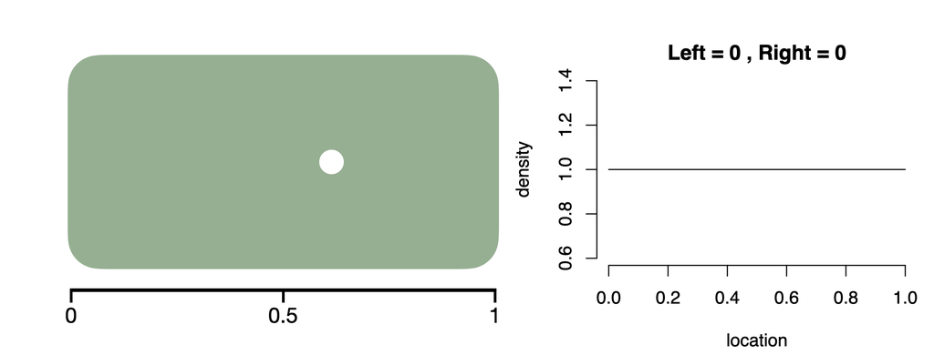

## Sequential analysis

**Example (Bayes’ experiment)**

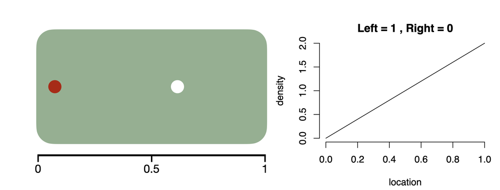

## Sequential analysis

**Example (Bayes’ experiment)**

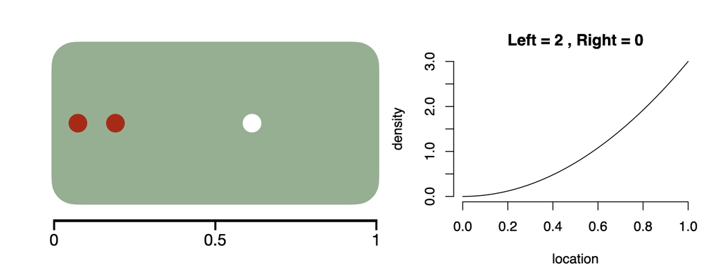

## Sequential analysis

**Example (Bayes’ experiment)**

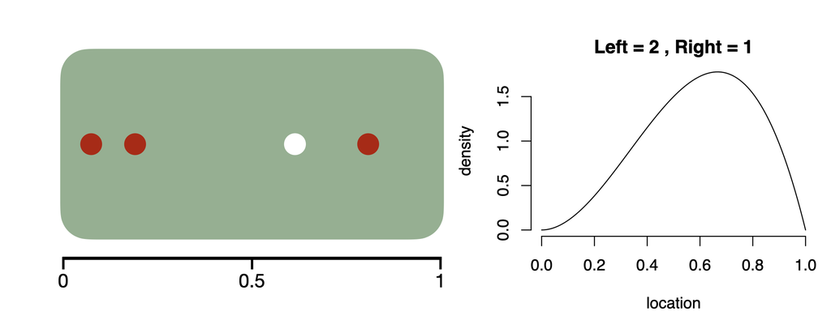

## Sequential analysis

**Example (Bayes’ experiment)**

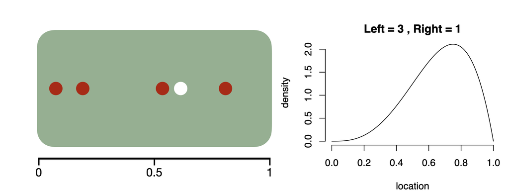

# Why Bayes?

## Uncertainty

Propagation of uncertainty

- Unified methods for any model (no need to transform to normal to access methodology)
- Inference for any quantities of interest
- Inference incorporating [model uncertainty](https://academic.oup.com/jrsssb/article/57/1/45/7035874)

## Simultaneous estimation

When using a single model, the posterior distribution contains all necessary information for inferences on the unobserved variables.

This eliminates the need to estimate components in sequence.

- Variable selection
- Time series
- [Examples from actuarial science](https://www.quinntechne.com/tag/bayesian/)

## Latent variables

- Missing data (Ch 8 in BDA3)
- Data fusion [example](https://doi.org/10.1111/j.1541-0420.2011.01725.x)
- Factor models [example](https://ani.stat.fsu.edu/~debdeep/factor_models.pdf)
- Regime switching [intro](https://scholar.harvard.edu/files/adegirmenci/files/hmm_adegirmenci_2014.pdf)

# Decision analysis

## Decision analysis

Examples

- Adaptive clinical trials
- Active learning [with Gaussian processes](https://bookdown.org/rbg/surrogates/chap6.html#chap6sequential)

## Loss functions

**Definition**

Let $\theta$ be an unknown state from a space of possible states $\Theta$,  
and let $a$ be an available action from set $A$.

The function $L(\theta, a) \in \mathbb{R}$ with $-\infty < L(\theta, a)$ is called a **loss function**.

Equivalently, we can call $U(\theta, a) := -L(\theta, a)$ a **utility function**.

## Loss functions

**Example**

Suppose you are on a first date, and you are interested in continuing to date this person.

The “state” is this person’s reciprocal interest, which is unknown to you.  
Let $\theta \in [0,1]$ with $0$ being total disinterest.

The “actions” available to you are  
$a_1=$ Give up and move on,  
$a_2=$ Let your date make the next move, and  
$a_3=$ Invite them on a second date.

Create a two-way table defining a valid loss (or utility) function for each state (discretized or step function) and action pair.

## Expected loss

**Definition**

Given a loss function $L(\theta, a) \in \mathbb{R}$ and probability distribution $\Pi$ on $\theta$, define the **expected loss** for any action as

$$\mathbb{E}_\Pi[L(\theta, a)] := \int_\Theta L(\theta, a) \, \Pi(\mbox{d}\theta) \, .$$

## Expected loss

**Dating example**

Suppose our belief about $\theta$ can be expressed with a beta distribution.

Calculate $\mathbb{E}_\Pi[L(\theta, a)]$ under each possible action.

## Making decisions

**Definition**

A **decision rule** maps available information in data $x$ to an action.

Frequentist **risk** averages the loss with respect to the distribution of $x$ instead of $\theta$.

**Bayes risk** averages over both.

Decisions can then be made by choosing the action or rule that:

- minimizes prior $\Pi(\theta)$ or posterior $\Pi(\theta \mid x)$ expected loss
- minimizes “risk” or “Bayes risk”
- follows the “minimax” principle

See [*Statistical Decision Theory and Bayesian Analysis*](https://link.springer.com/book/10.1007/978-1-4757-4286-2) by James Berger.

[figure not shown]